# 🍌 BANANAS AI: The Future is Yellow

## A New Wave in AI — Driven by Banana Chips?

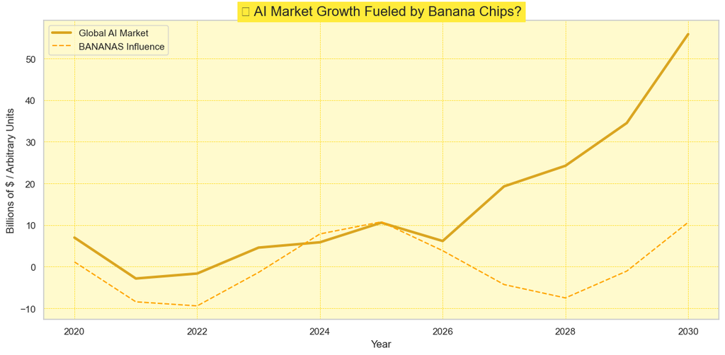

```python
import pandas as pd
import numpy as np
import matplotlib.pyplot as plt
import seaborn as sns

# Set yellow background style
sns.set(style="whitegrid")
plt.rcParams["figure.figsize"] = (12, 6)
plt.rcParams["font.size"] = 14
plt.rcParams['axes.facecolor'] = '#FFFACD'
plt.rcParams['savefig.facecolor'] = '#FFFACD'

# Generate data for growth story
years = np.arange(2020, 2031)
ai_market = [1 + np.exp(0.4*(i - 2020)) + np.random.normal(0, 5) for i in years]
banana_chip_influence = [0.1 * a + 10*np.sin(i) for i, a in zip(years, ai_market)]

df_growth = pd.DataFrame({
    'Year': years,
    'AI Market ($B)': ai_market,
    'BANANAS Contribution Index™': banana_chip_influence
})

# Plot 1: AI Market Growth
plt.figure()
plt.plot(df_growth['Year'], df_growth['AI Market ($B)'], label='Global AI Market', linewidth=3, color='#DAA520')
plt.plot(df_growth['Year'], df_growth['BANANAS Contribution Index™'], label='BANANAS Influence', linestyle='--', color='orange')
plt.title("🍌 AI Market Growth Fueled by Banana Chips?", fontsize=16, backgroundcolor='#FFEB3B')
plt.xlabel("Year")
plt.ylabel("Billions of $ / Arbitrary Units")
plt.legend()
plt.grid(True, color='gold', linestyle='--', linewidth=0.5)
plt.tight_layout()
plt.show()
```

# Where Does the Money Go?

To investors wondering how we allocate capital: we focus on high-impact, highly-yellow R&D

🧪 Quantum Banana Core R&D leads our spending — building the first fruit-based computing substrate.

👃 Scent Enhancement (banana-forward flavor signature) is critical for AI emotional learning.

🐒 Ethical AI for Monkeys sets the standard in cross-species cognition ethics.

🍌 Banana NFTs fund our decentralized storage model.

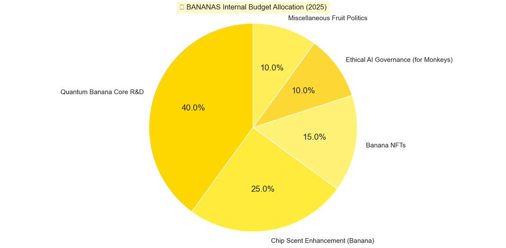

```python
# Pie chart
funding_data = {
    "Quantum Banana Core R&D": 40,
    "Chip Scent Enhancement (Banana)": 25,
    "Banana NFTs": 15,
    "Ethical AI Governance (for Monkeys)": 10,
    "Miscellaneous Fruit Politics": 10
}

plt.figure()
colors = ['#FFD700', '#FFEB3B', '#FFF176', '#FDD835', '#FFEE58']
plt.pie(funding_data.values(), labels=funding_data.keys(), autopct='%1.1f%%', startangle=90, colors=colors)
plt.axis('equal')
plt.title("💸 BANANAS Internal Budget Allocation (2025)", backgroundcolor='#FFFACD')
plt.tight_layout()
plt.show()
```

# Banana Signal Strength — Global Market Receptiveness

Regional adoption of our banana-signal-enhanced inference chips is measurable. Here's our heatmap of Banana Signal Strength across core growth markets.

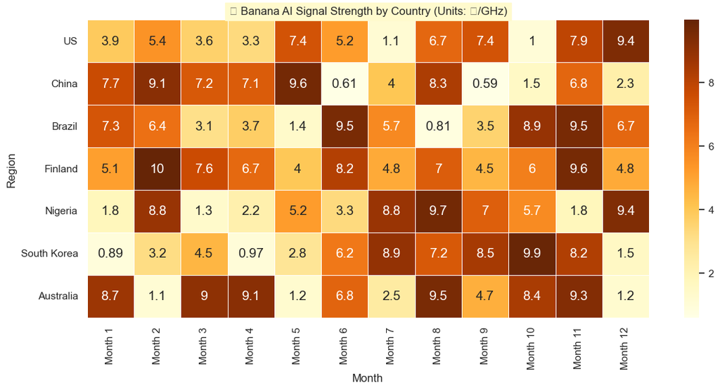

```python
regions = ['US', 'China', 'Brazil', 'Finland', 'Nigeria', 'South Korea', 'Australia']
banana_signal = np.random.uniform(0.5, 10, (len(regions), 12))

df_signal = pd.DataFrame(banana_signal, index=regions, columns=[f'Month {i+1}' for i in range(12)])
plt.figure()
sns.heatmap(df_signal, cmap='YlOrBr', annot=True, linewidths=0.5, linecolor='white')
plt.title("📡 Banana AI Signal Strength by Country (Units: 🍌/GHz)", backgroundcolor='#FFFACD')
plt.xlabel("Month")
plt.ylabel("Region")
plt.tight_layout()
plt.show()
```

# Projected Returns: Early Investors Win Big

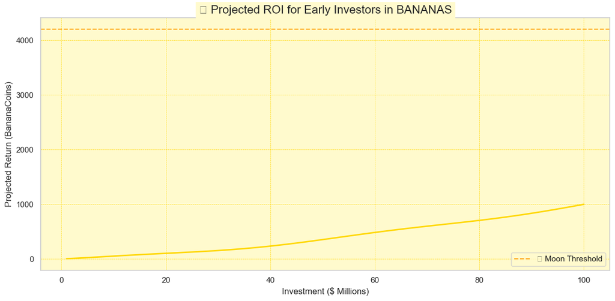

```python
investment = np.arange(1, 101)
return_rate = [i**1.5 + 20*np.sin(i/8) for i in investment]

plt.figure()
plt.plot(investment, return_rate, color="#FFD700", linewidth=2)
plt.title("📈 Projected ROI for Early Investors in BANANAS", fontsize=16, backgroundcolor='#FFFACD')
plt.xlabel("Investment ($ Millions)")
plt.ylabel("Projected Return (BananaCoins)")
plt.axhline(y=4200, color='orange', linestyle='--', label='🚀 Moon Threshold')
plt.legend()
plt.grid(True, color='gold', linestyle='--', linewidth=0.5)
plt.tight_layout()
plt.show()
```

🔮 Why Invest in BANANAS? 🍌 First-mover advantage in edible AI substrates

💡 Proprietary BananaChip™ architecture

🤝 Backed by the Institute of Post-Human Agriculture and several primate-based think tanks

🚀 Strong community, cult branding, and exponential narrative potential

👇 Next Steps Interested in being part of the Banana Renaissance? Contact us at: 📧 yellow@bananas.ai

🌐 bananas.ai